# AllLifeBank

### Visualize Decision tree with tuned hyperparameters

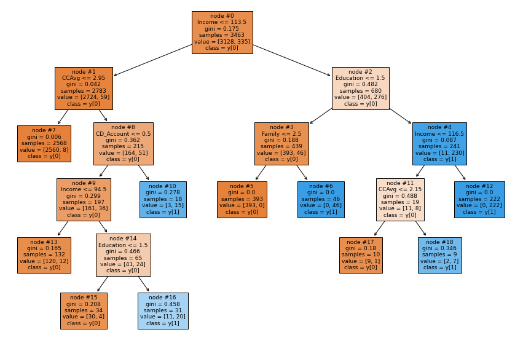

```python
plt.figure(figsize=(15,10))

tree.plot_tree(estimator,feature_names=feature_names,filled=True,fontsize=9,node_ids=True,class_names=True)
plt.show()
```

```python
# Text report showing the rules of a decision tree -

print(tree.export_text(estimator,feature_names=feature_names,show_weights=True))
```

```
|--- Income <= 113.50
|   |--- CCAvg <= 2.95
|   |   |--- weights: [2560.00, 8.00] class: 0
|   |--- CCAvg >  2.95
|   |   |--- CD_Account <= 0.50
|   |   |   |--- Income <= 94.50
|   |   |   |   |--- weights: [120.00, 12.00] class: 0
|   |   |   |--- Income >  94.50
|   |   |   |   |--- Education <= 1.50
|   |   |   |   |   |--- weights: [30.00, 4.00] class: 0
|   |   |   |   |--- Education >  1.50
|   |   |   |   |   |--- weights: [11.00, 20.00] class: 1
|   |   |--- CD_Account >  0.50
|   |   |   |--- weights: [3.00, 15.00] class: 1
|--- Income >  113.50
|   |--- Education <= 1.50
|   |   |--- Family <= 2.50
|   |   |   |--- weights: [393.00, 0.00] class: 0
|   |   |--- Family >  2.50
|   |   |   |--- weights: [0.00, 46.00] class: 1
|   |--- Education >  1.50
|   |   |--- Income <= 116.50
|   |   |   |--- CCAvg <= 2.15
|   |   |   |   |--- weights: [9.00, 1.00] class: 0
|   |   |   |--- CCAvg >  2.15
|   |   |   |   |--- weights: [2.00, 7.00] class: 1
|   |   |--- Income >  116.50
|   |   |   |--- weights: [0.00, 222.00] class: 1
```

```python
# importance of features in the tree building ( The importance of a feature is computed as the
#(normalized) total reduction of the 'criterion' brought by that feature. It is also known as the Gini importance )

print (pd.DataFrame(estimator.feature_importances_, columns = ["Imp"], index = X_train.columns).sort_values(by = 'Imp', ascending = False))
```

```
                         Imp
Education           0.435655
Income              0.336063
Family              0.153584
CCAvg               0.048663
CD_Account          0.026036
Age                 0.000000
Experience          0.000000
ZIPCode             0.000000
Mortgage            0.000000
Securities_Account  0.000000
Online              0.000000
CreditCard          0.000000
```

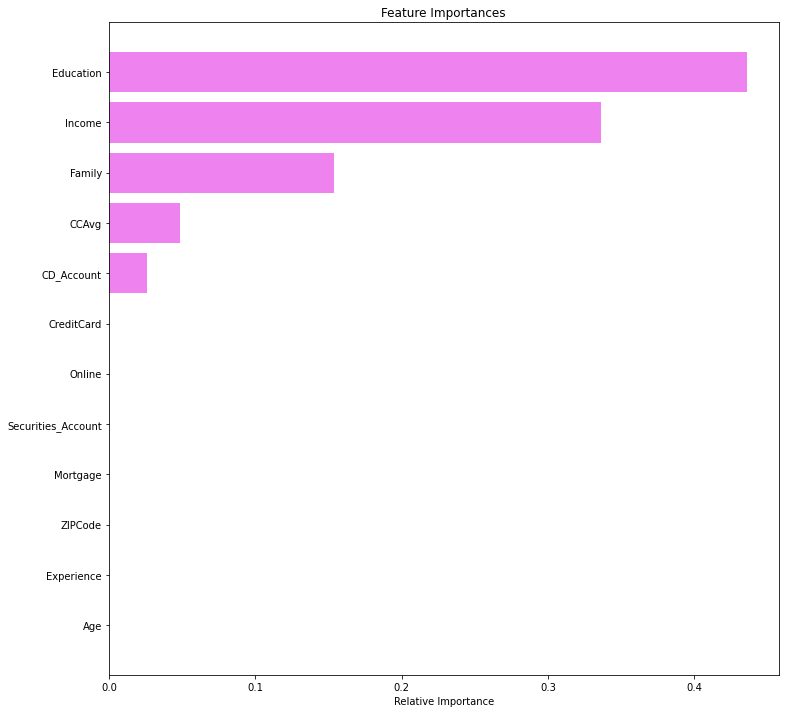

```python
#So the key feature importants are Education, Income, Family, CCAvg, CD_Account

importances = estimator.feature_importances_
indices = np.argsort(importances)

plt.figure(figsize=(12,12))
plt.title('Feature Importances')
plt.barh(range(len(indices)), importances[indices], color='violet', align='center')
plt.yticks(range(len(indices)), [feature_names[i] for i in indices])
plt.xlabel('Relative Importance')
plt.show()
```

- We have received recall training set as 0.92 which is increased from 0.86.
- We will use post-prune to see the result. It might give good result.

### Cost Complexity Pruning

The DecisionTreeClassifier provides parameters such as min_samples_leaf and max_depth to prevent a tree from overfiting. Cost complexity pruning provides another option to control the size of a tree. In DecisionTreeClassifier, this pruning technique is parameterized by the cost complexity parameter, ccp_alpha. Greater values of ccp_alpha increase the number of nodes pruned. Here we only show the effect of ccp_alpha on regularizing the trees and how to choose a ccp_alpha based on validation scores.

### Total impurity of leaves vs effective alphas of pruned tree

Minimal cost complexity pruning recursively finds the node with the "weakest link". The weakest link is characterized by an effective alpha, where the nodes with the smallest effective alpha are pruned first. To get an idea of what values of ccp_alpha could be appropriate, scikit-learn provides DecisionTreeClassifier.cost_complexity_pruning_path that returns the effective alphas and the corresponding total leaf impurities at each step of the pruning process. As alpha increases, more of the tree is pruned, which increases the total impurity of its leaves.

```python
clf = DecisionTreeClassifier(random_state=1)
path = clf.cost_complexity_pruning_path(X_train, y_train)
ccp_alphas, impurities = path.ccp_alphas, path.impurities
```

```python
pd.DataFrame(path)
```

|  | ccp_alphas | impurities |
| --- | --- | --- |
| 0 | 0.000000 | 0.000000 |
| 1 | 0.000270 | 0.001078 |
| 2 | 0.000270 | 0.001617 |
| 3 | 0.000274 | 0.002164 |
| 4 | 0.000284 | 0.002733 |
| 5 | 0.000334 | 0.003734 |
| 6 | 0.000351 | 0.004787 |
| 7 | 0.000385 | 0.005172 |
| 8 | 0.000449 | 0.006070 |
| 9 | 0.000480 | 0.007030 |
| 10 | 0.000510 | 0.009583 |
| 11 | 0.000520 | 0.010103 |
| 12 | 0.000520 | 0.010622 |
| 13 | 0.000527 | 0.014837 |
| 14 | 0.000536 | 0.015374 |
| 15 | 0.000674 | 0.017395 |
| 16 | 0.000743 | 0.018138 |
| 17 | 0.000798 | 0.018936 |
| 18 | 0.000969 | 0.019905 |
| 19 | 0.001257 | 0.021162 |
| 20 | 0.002277 | 0.025716 |
| 21 | 0.003388 | 0.029104 |
| 22 | 0.004032 | 0.033136 |
| 23 | 0.006279 | 0.039415 |
| 24 | 0.023783 | 0.063198 |
| 25 | 0.055780 | 0.174758 |

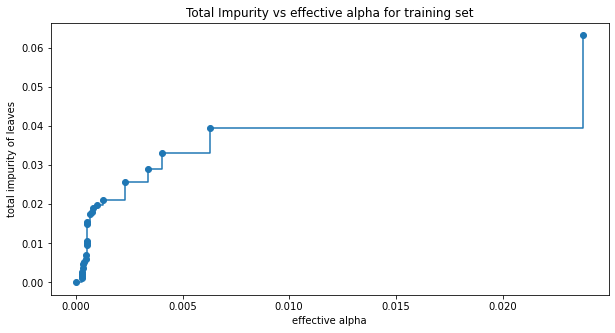

```python
fig, ax = plt.subplots(figsize=(10,5))
ax.plot(ccp_alphas[:-1], impurities[:-1], marker='o', drawstyle="steps-post")
ax.set_xlabel("effective alpha")
ax.set_ylabel("total impurity of leaves")
ax.set_title("Total Impurity vs effective alpha for training set")
plt.show()
```

```python
clfs = []
for ccp_alpha in ccp_alphas:
    clf = DecisionTreeClassifier(random_state=1, ccp_alpha=ccp_alpha)
    clf.fit(X_train, y_train)
    clfs.append(clf)
print("Number of nodes in the last tree is: {} with ccp_alpha: {}".format(
      clfs[-1].tree_.node_count, ccp_alphas[-1]))
```

```
Number of nodes in the last tree is: 1 with ccp_alpha: 0.05577997576470471
```

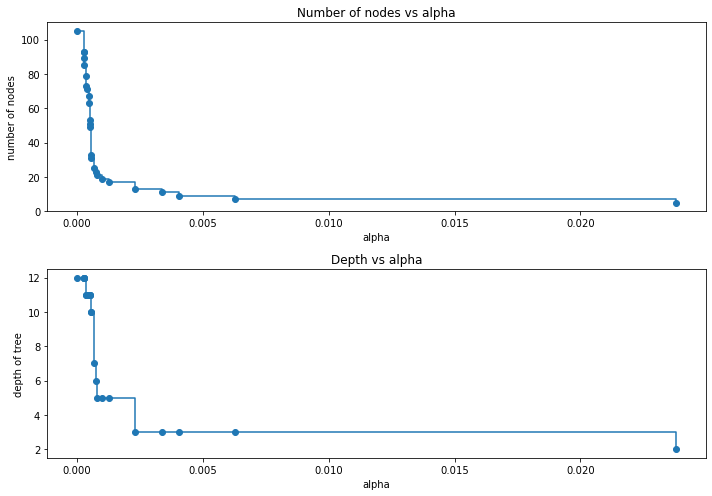

```python
clfs = clfs[:-1]
ccp_alphas = ccp_alphas[:-1]

node_counts = [clf.tree_.node_count for clf in clfs]
depth = [clf.tree_.max_depth for clf in clfs]
fig, ax = plt.subplots(2, 1,figsize=(10,7))
ax[0].plot(ccp_alphas, node_counts, marker='o', drawstyle="steps-post")
ax[0].set_xlabel("alpha")
ax[0].set_ylabel("number of nodes")
ax[0].set_title("Number of nodes vs alpha")
ax[1].plot(ccp_alphas, depth, marker='o', drawstyle="steps-post")
ax[1].set_xlabel("alpha")
ax[1].set_ylabel("depth of tree")
ax[1].set_title("Depth vs alpha")
fig.tight_layout()
```

### Accuracy vs alpha for training and testing sets

When we have ccp_alpha = 0 and keeping the other default parameters of DecisionTreeClassifier, the tree overfits, leading to a 100% training accuracy and 98% testing accuracy.

As alpha increases, more of the tree is pruned, thus creating a decision tree that generalizes better.

```python
train_scores = [clf.score(X_train, y_train) for clf in clfs]
test_scores = [clf.score(X_test, y_test) for clf in clfs]
```

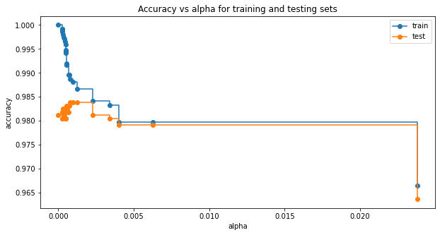

```python
fig, ax = plt.subplots(figsize=(10,5))
ax.set_xlabel("alpha")
ax.set_ylabel("accuracy")
ax.set_title("Accuracy vs alpha for training and testing sets")
ax.plot(ccp_alphas, train_scores, marker='o', label="train",
        drawstyle="steps-post")
ax.plot(ccp_alphas, test_scores, marker='o', label="test",
        drawstyle="steps-post")
ax.legend()
plt.show()
```

```python
index_best_model = np.argmax(test_scores)
best_model = clfs[index_best_model]
print(best_model)
print('Training accuracy of best model: ',best_model.score(X_train, y_train))
print('Test accuracy of best model: ',best_model.score(X_test, y_test))
```

```
DecisionTreeClassifier(ccp_alpha=0.0007984340047719738, random_state=1)
Training accuracy of best model:  0.9887380883626913
Test accuracy of best model:  0.9838383838383838
```

- We have received Accuracy of Training and Test is 0.98. This is good fit. But we will see again the recall result

```python
recall_train=[]
for clf in clfs:
    pred_train3=clf.predict(X_train)
    values_train=metrics.recall_score(y_train,pred_train3)
    recall_train.append(values_train)
```

```python
recall_test=[]
for clf in clfs:
    pred_test3=clf.predict(X_test)
    values_test=metrics.recall_score(y_test,pred_test3)
    recall_test.append(values_test)
```

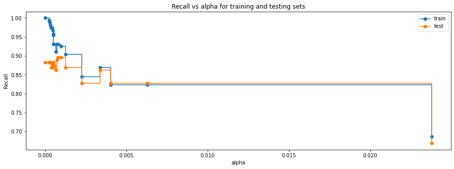

```python
fig, ax = plt.subplots(figsize=(15,5))
ax.set_xlabel("alpha")
ax.set_ylabel("Recall")
ax.set_title("Recall vs alpha for training and testing sets")
ax.plot(ccp_alphas, recall_train, marker='o', label="train",
        drawstyle="steps-post")
ax.plot(ccp_alphas, recall_test, marker='o', label="test",
        drawstyle="steps-post")
ax.legend()
plt.show()
```

```python
# creating the model where we get highest train and test recall
index_best_model = np.argmax(recall_test)
best_model = clfs[index_best_model]
print(best_model)
```

```
DecisionTreeClassifier(ccp_alpha=0.0007984340047719738, random_state=1)
```

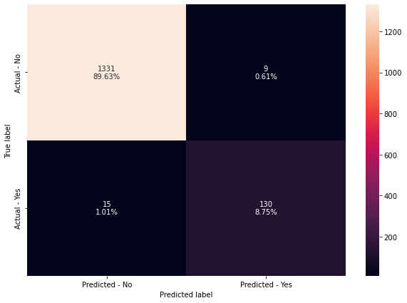

```python
make_confusion_matrix(best_model,y_test)
```

```python
# Recall on train and test
get_recall_score(best_model)
```

```
Recall on training set :  0.9313432835820895
Recall on test set :  0.896551724137931
```

- Recall score is increased from the previous result. Hence the best recall score is 0.93.
- Lets compare all recall values of test and training

## Comparing all the decision tree models

```python
comparison_frame = pd.DataFrame({'Model':['Initial decision tree model','Decision tree with restricted maximum depth=4','Decision treee with hyperparameter tuning',
                                         'Decision tree with post-pruning'], 'Train_Recall':[1,0.86,0.92,0.93], 'Test_Recall':[0.88,0.84,0.89,0.89]})
comparison_frame
```

|  | Model | Train_Recall | Test_Recall |
| --- | --- | --- | --- |
| 0 | Initial decision tree model | 1.00 | 0.88 |
| 1 | Decision tree with restricted maximum depth=4 | 0.86 | 0.84 |
| 2 | Decision treee with hyperparameter tuning | 0.92 | 0.89 |
| 3 | Decision tree with post-pruning | 0.93 | 0.89 |

## Actionable Insights & Recommendations

#### Comparison between Logistic regression and Decision Tree

```python
# testing performance comparison

models_test_comp_df = pd.concat(
    [
        log_reg_model_test_perf.T,
        log_reg_model_test_perf_threshold_auc_roc.T,
        log_reg_model_test_perf_threshold_curve.T,
    ],
    axis=1,
)
models_test_comp_df.columns = [
    "Logistic Regression sklearn",
    "Logistic Regression-0.07 Threshold",
    "Logistic Regression-0.32 Threshold",
]
print("Test set performance comparison:")
models_test_comp_df
```

```
Test set performance comparison:
```

|  | Logistic Regression sklearn | Logistic Regression-0.07 Threshold | Logistic Regression-0.32 Threshold |
| --- | --- | --- | --- |
| Accuracy | 0.952189 | 0.879461 | 0.945455 |
| Recall | 0.648276 | 0.910345 | 0.724138 |
| Precision | 0.824561 | 0.442953 | 0.719178 |
| F1 | 0.725869 | 0.595937 | 0.721649 |

```python
comparison_frame = pd.DataFrame({'Model':['Initial decision tree model','Decision tree with restricted maximum depth=4','Decision treee with hyperparameter tuning',
                                         'Decision tree with post-pruning'], 'Train_Recall':[1,0.86,0.92,0.93], 'Test_Recall':[0.88,0.84,0.89,0.89]})
comparison_frame
```

|  | Model | Train_Recall | Test_Recall |
| --- | --- | --- | --- |
| 0 | Initial decision tree model | 1.00 | 0.88 |
| 1 | Decision tree with restricted maximum depth=4 | 0.86 | 0.84 |
| 2 | Decision treee with hyperparameter tuning | 0.92 | 0.89 |
| 3 | Decision tree with post-pruning | 0.93 | 0.89 |

### Key points to Marketing team for campaign

- Age - Most of the customers are from age 35 to 55
- Income - Most of the customer's income is less than 100k.
- ZIPCode - more than 50% of zipcode area's customers didnt accept loan. Bank can focus these areas people to expand their business.
- Family - Three-member family count is lesser than others. Single person count is higher than others
- CCAvg - This is right-skewed and it has a lot of outliers. Most of the customers are spending amounts on credit cards average from 0.5 to 3 thousand in a month
- Education - All customers are educated. The undergraduate count must be from 2000 to 2250. Graduates and professionals count must be from 1250 to 1500
- Mortgage - 3462 customers have no mortgage. customers who have Mortgage loans mostly from 0.5 to 100 thousand.
- Personal_Loan - 4520 customers didn't accept personal loan from the last campaign. So the bank can focus on these customers.
- Securities_Account - 4478 customers have no security deposit in the bank
- CD_Account - 4698 customers have no CD_Account
- Online - 2016 customers have no online account
- CreditCard - 3530 customers have no credit cards (Excluding from AllLifeBank). The rest of the customers 1470 are having credit cards in other banks.